# Red Wine Quality by Kunio Shimizu

But from the graph, it is looks like volatile.acidity is more negatively correlated to quality of the red wine.

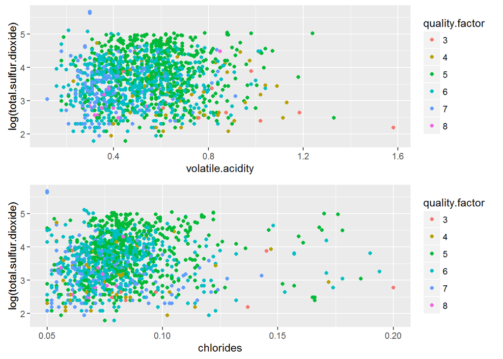

It is looks like the total.sulfur.dioxide might have negative impact on the quality of the red wine, but it might not be case as well by looking at the last plot.

Finally plotting two strongest both negative and positive attributes to the quality of alcohol;

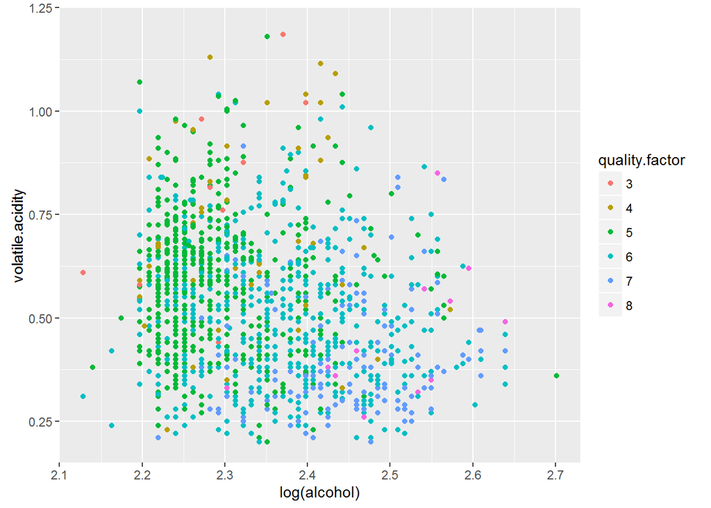

Its clear that high level of alcohol and low level of volatile.acidity definitely gives high quality of wine.

One things that notice that from seeing above plot, it seems that quality “4” appears any kinds of level of attributes, and it seems like there is no relationships to attributes, even though the sample of quality 4 is small.

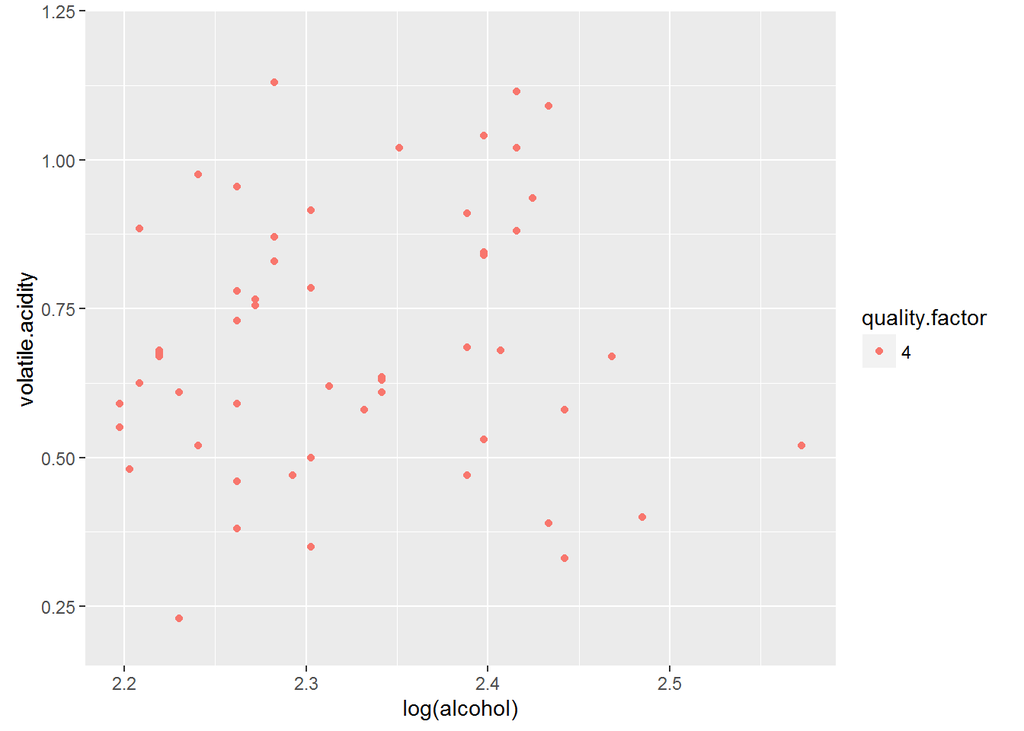

No, it looks there are very weak trends that as alcohol level get higher, quality 4 wine appearance decrease. But it looks like even volatile.acidity decrease, the appearance of quality 4 wine would not decrease for any level of volatile acidity. This is interesting.

Finally, I modify the dataset in the group of each quality of wine, and shows the conditional mean and median for each quality of the wine.

```
## Source: local data frame [6 x 5]
##
##   quality.factor median.citric.acid median.sulphates median.alcohol     n
##           (fctr)              (dbl)            (dbl)          (dbl) (int)
## 1              3              0.035            0.545          9.925    10
## 2              4              0.090            0.560         10.000    53
## 3              5              0.230            0.580          9.700   681
## 4              6              0.260            0.640         10.500   638
## 5              7              0.400            0.740         11.500   199
## 6              8              0.420            0.740         12.150    18
```

```
## Source: local data frame [6 x 5]
##
##   quality.factor median.vola.acidity median.chlorides
##           (fctr)               (dbl)            (dbl)
## 1              3               0.845           0.0905
## 2              4               0.670           0.0800
## 3              5               0.580           0.0810
## 4              6               0.490           0.0780
## 5              7               0.370           0.0730
## 6              8               0.370           0.0705
## Variables not shown: median.tot.sulfur.dio (dbl), n (int)
```

From the table above, I can confirm the previous plot analysis and directions of the attributes effect on quality.

Only variable I am not clear is total.sulfur.dioxide. I shows the negative relationships on quality of red wine, but it seems like low level of total sulfur dioxide also sored low level of quality.

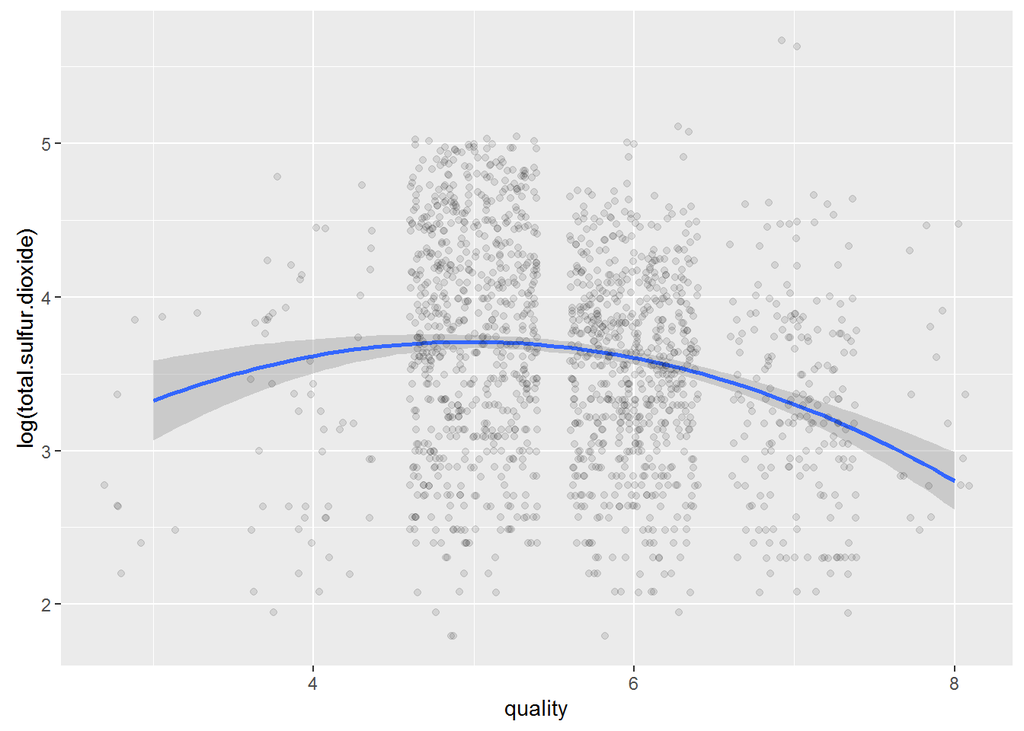

The above plot, I add non-liner lm model (y = poly(x,2)) fitted line on the scatter plot. The line is concave, and it might be the case that the either high level of total.sulfur.dioxide and low one is determine the good and bad of quality of wine, with the combination of the other attributes.

First, I build the liner model (inducing log transformation of some attributes) to see the relationship of each attributes and quality of the wine.

```r
#model 1
f1 <- (quality ~ . -quality.factor)
model1 <- lm(f1, data = wine)

#model 2
f2 <- (quality ~ fixed.acidity + volatile.acidity + citric.acid + residual.sugar +
         chlorides + log(free.sulfur.dioxide) + log(total.sulfur.dioxide) + density +
         pH + sulphates + log(alcohol) -quality.factor)
model2 <- lm(f2, data = wine)

#model 3
f3 <- (quality ~ volatile.acidity + chlorides +
         log(free.sulfur.dioxide) + log(total.sulfur.dioxide) +
         pH + sulphates + log(alcohol) - quality.factor)
model3 <- lm(f3, data = wine)
```

```
##
## Calls:
## model1: lm(formula = f1, data = wine)
## model2: lm(formula = f2, data = wine)
## model3: lm(formula = f3, data = wine)
##
## ================================================================
##                                model1      model2     model3
## ----------------------------------------------------------------
##   (Intercept)                 21.965      15.238      0.351
##                              (21.195)    (21.438)    (0.548)
##   fixed.acidity                0.025       0.032
##                               (0.026)     (0.026)
##   volatile.acidity            -1.084***   -1.122***  -1.034***
##                               (0.121)     (0.120)    (0.101)
##   citric.acid                 -0.183      -0.233
##                               (0.147)     (0.146)
##   residual.sugar               0.016       0.012
##                               (0.015)     (0.015)
##   chlorides                   -1.874***   -1.716***  -1.917***
##                               (0.419)     (0.418)    (0.399)
##   free.sulfur.dioxide          0.004*
##                               (0.002)
##   total.sulfur.dioxide        -0.003***
##                               (0.001)
##   density                    -17.881     -15.288
##                              (21.633)    (21.601)
##   pH                          -0.414*     -0.360     -0.455***
##                               (0.192)     (0.190)    (0.118)
##   sulphates                    0.916***    0.906***   0.883***
##                               (0.114)     (0.115)    (0.111)
##   alcohol                      0.276***
##                               (0.026)
##   log(free.sulfur.dioxide)                 0.106**    0.119**
##                                           (0.040)    (0.039)
##   log(total.sulfur.dioxide)               -0.154***  -0.171***
##                                           (0.041)    (0.039)
##   log(alcohol)                             3.004***   3.095***
##                                           (0.283)    (0.185)
## ----------------------------------------------------------------
##   R-squared                       0.4         0.4         0.4
##   adj. R-squared                  0.4         0.4         0.4
##   sigma                           0.6         0.6         0.6
##   F                              81.3        80.5       126.1
##   p                               0.0         0.0         0.0
##   Log-likelihood              -1569.1     -1572.2     -1573.9
##   Deviance                      666.4       669.0       670.4
##   AIC                          3164.3      3170.4      3165.8
##   BIC                          3234.2      3240.3      3214.2
##   N                            1599        1599        1599
## ================================================================
```

I created three kinds of model, model 1: is just the liner model of all attributes. model 2: is created the skewed attributes transformed by log. model 3: is created by using just statistically significant attributes.

Finally, I also construct 3 same models using new data set, wine.refine, which are “residual.sugar” and “chorides” and “sulphates” outliers removed by 1.5IRQ rules.

```r
summary(wine.refine)
```

```
##  fixed.acidity    volatile.acidity  citric.acid     residual.sugar
##  Min.   : 4.600   Min.   :0.1200   Min.   :0.0000   Min.   :0.900
##  1st Qu.: 7.100   1st Qu.:0.3900   1st Qu.:0.0850   1st Qu.:1.900
##  Median : 7.900   Median :0.5200   Median :0.2400   Median :2.100
##  Mean   : 8.228   Mean   :0.5258   Mean   :0.2544   Mean   :2.184
##  3rd Qu.: 9.100   3rd Qu.:0.6350   3rd Qu.:0.4000   3rd Qu.:2.500
##  Max.   :15.000   Max.   :1.3300   Max.   :0.7500   Max.   :3.600
##    chlorides      free.sulfur.dioxide total.sulfur.dioxide
##  Min.   :0.0120   Min.   : 1.00       Min.   :  6.00
##  1st Qu.:0.0690   1st Qu.: 8.00       1st Qu.: 23.00
##  Median :0.0780   Median :14.00       Median : 37.00
##  Mean   :0.0779   Mean   :15.69       Mean   : 44.93
##  3rd Qu.:0.0865   3rd Qu.:21.00       3rd Qu.: 60.00
##  Max.   :0.1190   Max.   :57.00       Max.   :165.00
##     density             pH          sulphates         alcohol
##  Min.   :0.9901   Min.   :2.860   Min.   :0.3300   Min.   : 8.40
##  1st Qu.:0.9955   1st Qu.:3.220   1st Qu.:0.5500   1st Qu.: 9.50
##  Median :0.9966   Median :3.320   Median :0.6100   Median :10.10
##  Mean   :0.9966   Mean   :3.324   Mean   :0.6329   Mean   :10.42
##  3rd Qu.:0.9976   3rd Qu.:3.410   3rd Qu.:0.7050   3rd Qu.:11.00
##  Max.   :1.0014   Max.   :4.010   Max.   :0.9900   Max.   :14.00
##     quality      quality.factor
##  Min.   :3.000   3:  4
##  1st Qu.:5.000   4: 39
##  Median :6.000   5:571
##  Mean   :5.643   6:546
##  3rd Qu.:6.000   7:156
##  Max.   :8.000   8: 15
```

```r
str(wine.refine)
```

```
## 'data.frame':    1331 obs. of  13 variables:
##  $ fixed.acidity       : num  7.4 7.8 7.8 11.2 7.4 7.4 7.9 7.3 7.8 6.7 ...
##  $ volatile.acidity    : num  0.7 0.88 0.76 0.28 0.7 0.66 0.6 0.65 0.58 0.58 ...
##  $ citric.acid         : num  0 0 0.04 0.56 0 0 0.06 0 0.02 0.08 ...
##  $ residual.sugar      : num  1.9 2.6 2.3 1.9 1.9 1.8 1.6 1.2 2 1.8 ...
##  $ chlorides           : num  0.076 0.098 0.092 0.075 0.076 0.075 0.069 0.065 0.073 0.097 ...
##  $ free.sulfur.dioxide : num  11 25 15 17 11 13 15 15 9 15 ...
##  $ total.sulfur.dioxide: num  34 67 54 60 34 40 59 21 18 65 ...
##  $ density             : num  0.998 0.997 0.997 0.998 0.998 ...
##  $ pH                  : num  3.51 3.2 3.26 3.16 3.51 3.51 3.3 3.39 3.36 3.28 ...
##  $ sulphates           : num  0.56 0.68 0.65 0.58 0.56 0.56 0.46 0.47 0.57 0.54 ...
##  $ alcohol             : num  9.4 9.8 9.8 9.8 9.4 9.4 9.4 10 9.5 9.2 ...
##  $ quality             : int  5 5 5 6 5 5 5 7 7 5 ...
##  $ quality.factor      : Factor w/ 6 levels "3","4","5","6",..: 3 3 3 4 3 3 3 5 5 3 ...
```

Constructing similar model from above.

```r
#model 4
f4 <- (quality ~ . -quality.factor)
model4 <- lm(f4, data = wine.refine)

#model 5
f5 <- (quality ~ fixed.acidity + volatile.acidity + citric.acid + residual.sugar +
         chlorides + log(free.sulfur.dioxide) + log(total.sulfur.dioxide) + density +
         pH + sulphates + log(alcohol) - quality.factor)
model5 <- lm(f5, data = wine.refine)

#model 6
f6 <- (quality ~ volatile.acidity + chlorides +
         log(free.sulfur.dioxide) + log(total.sulfur.dioxide) +
         pH + sulphates + log(alcohol) - quality.factor)
model6 <- lm(f6, data = wine.refine)
```

```
##
## Calls:
## model4: lm(formula = f4, data = wine.refine)
## model5: lm(formula = f5, data = wine.refine)
## model6: lm(formula = f6, data = wine.refine)
##
## ================================================================
##                                model4      model5     model6
## ----------------------------------------------------------------
##   (Intercept)                 62.362*     57.369*     0.449
##                              (25.985)    (26.148)    (0.596)
##   fixed.acidity                0.053       0.056*
##                               (0.028)     (0.028)
##   volatile.acidity            -0.871***   -0.889***  -0.790***
##                               (0.129)     (0.128)    (0.106)
##   citric.acid                 -0.261      -0.285
##                               (0.156)     (0.154)
##   residual.sugar               0.044       0.040
##                               (0.049)     (0.049)
##   chlorides                   -1.323      -1.468     -2.535*
##                               (1.301)     (1.303)    (1.212)
##   free.sulfur.dioxide          0.004
##                               (0.002)
##   total.sulfur.dioxide        -0.003**
##                               (0.001)
##   density                    -58.835*    -57.153*
##                              (26.488)    (26.290)
##   pH                          -0.457*     -0.440*    -0.615***
##                               (0.204)     (0.204)    (0.122)
##   sulphates                    1.821***    1.828***   1.702***
##                               (0.164)     (0.164)    (0.153)
##   alcohol                      0.234***
##                               (0.032)
##   log(free.sulfur.dioxide)                 0.108*     0.131**
##                                           (0.043)    (0.042)
##   log(total.sulfur.dioxide)               -0.133**   -0.158***
##                                           (0.043)    (0.041)
##   log(alcohol)                             2.498***   2.996***
##                                           (0.337)    (0.199)
## ----------------------------------------------------------------
##   R-squared                       0.4         0.4         0.4
##   adj. R-squared                  0.4         0.4         0.4
##   sigma                           0.6         0.6         0.6
##   F                              80.9        80.5       124.6
##   p                               0.0         0.0         0.0
##   Log-likelihood              -1214.6     -1216.0     -1220.6
##   Deviance                      483.4       484.4       487.8
##   AIC                          2455.1      2457.9      2459.3
##   BIC                          2522.6      2525.5      2506.0
##   N                            1331        1331        1331
## ================================================================
```

It does not change anything in terms of adjusted R squire. But the BIC is smallest in model 6, so I chose model 6 is best predictive model.

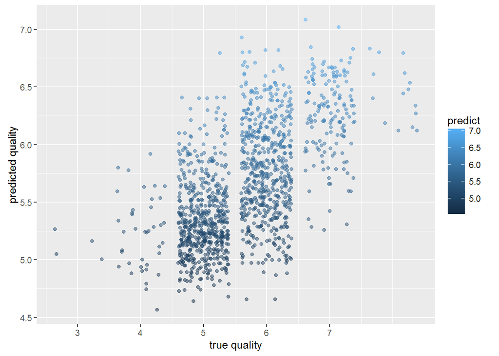

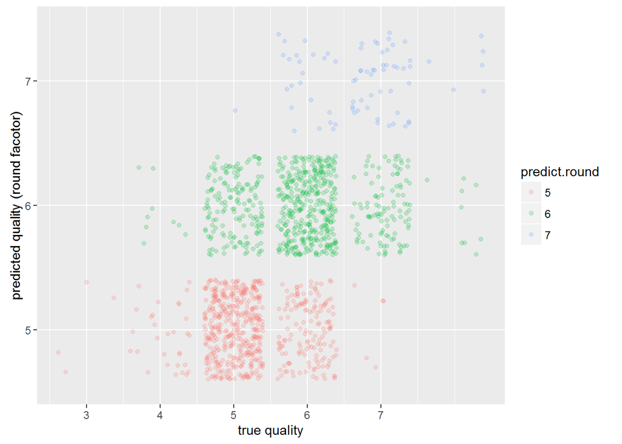

I also plotted true quality of wine and predicted quality of wine by model 6.

It is seems like that model predict quality well. But there are some miss predictions.

Second plot, I transformed predicted quality to discrete factor integer by round by 0 digit.

# Multivariate Analysis

### Talk about some of the relationships you observed in this part of the investigation. Were there features that strengthened each other in terms of looking at your feature(s) of interest?

It is interesting to see that, out of all positively related attributes on wine quality, citric.acid, sulphates, and alcohol, alcohol seems to have strongest positive relationship on red wine quality. Also, it is look like, even other positive attributes are low in score, if the alcohol level is high enough, wine was graded relatively high.

### Were there any interesting or surprising interactions between features?

Total.sulur.dioxide, one of the negative attributes on the red wine quality, seems have non-liner distribution on the quality of red wine. Generally I can see as total.sulfur.dioxide gets low, the quality of wine increase, but, when the total.sulfur.dioxide has very low, I can see both good quality wine over 6, and also low quality wine 4.

### OPTIONAL: Did you create any models with your dataset? Discuss the strengths and limitations of your model.

I created 6 models, 3 with full sample, and 3 with outliers excluded sample. Each 3 model consist with simple liner model, log-transformed model, log-transformed with statistically significant attributes. As I suspected in plots, it is look like volatile.acidity, chlorides, sulphates, alcohol, free.sulfur.diocide, and total.sulfur.dioxides t values were significant, and signs (positive or negative) are correct. Last final plot was actually wine quality and predicted quality (rounding up the decimal number).

The R-2 was quite low of 40%, and my prediction only predict in the range of 5,6,7 quality, but generality, prediction and actual quality correspond each other.

# Final Plots and Summary

### Plot One

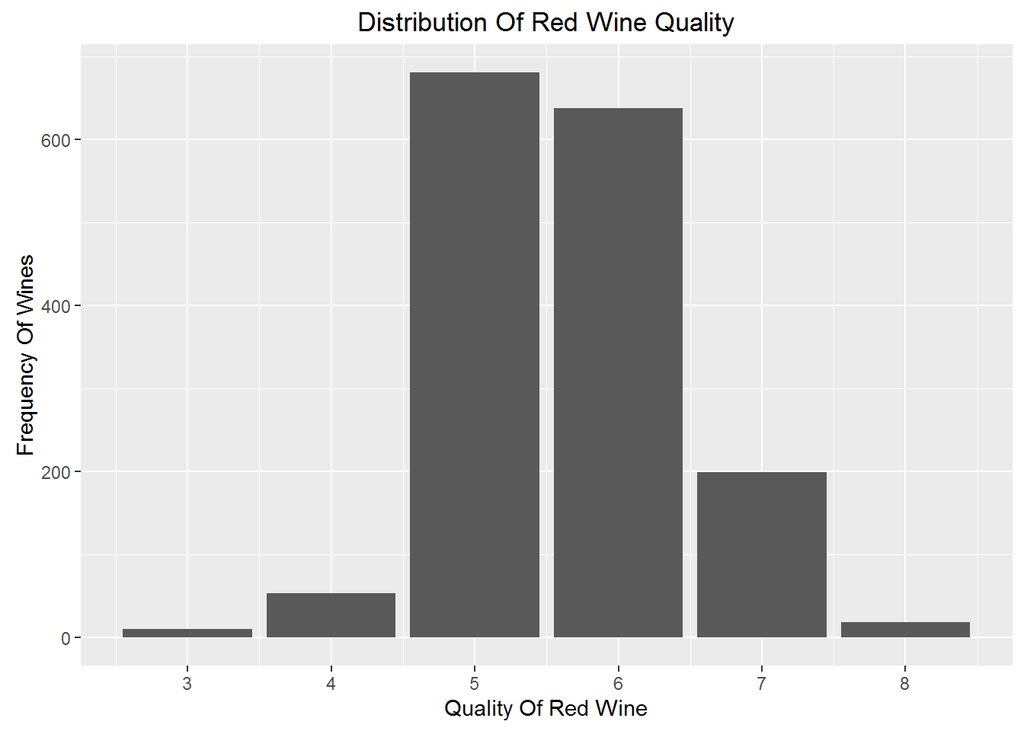

### Description One

The wine quality scales are from 1 to 10, but most of the wines fall into 5 and 6 quality. The mode quality is 5, median quality is 6, and mean quality is 5.636.

### Plot Two

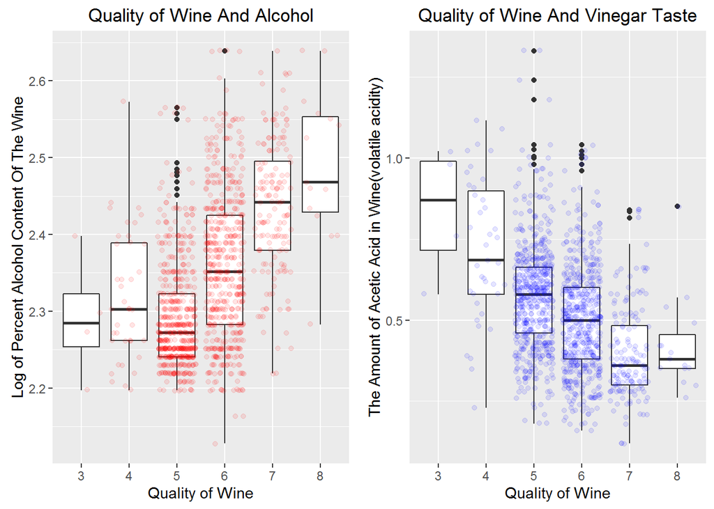

### Description Two

Above plot describe the relationship between the quality of wine and these strongest at attributes in it.

Left plot x-axis is the quality of wine, and y-axis is the log of alcohol % content in the wine. Inside plot the box plot describe the mean and percentile of the log of alcohol % content. As it can be seen that as the alcohol level increase, the quality of wine tends to increase. Although, it looks like if the quality level of wine is around 3-4, alcohol % level is high, but it might be misleading because of less sample size.

Right plot has same x-axis but the y axis is the amount of acetic acid in wine, volatile acidity, it is also known, “Vinegar taste”. It is clear to see that the level of “vinegar taste” decrease, the quality of wine increased.

From above plot, plotting two strong related with quality of wine, it is looks like, more alcohol and less vinegar tasted wine tends to have high quality of wine.

### Plot Three

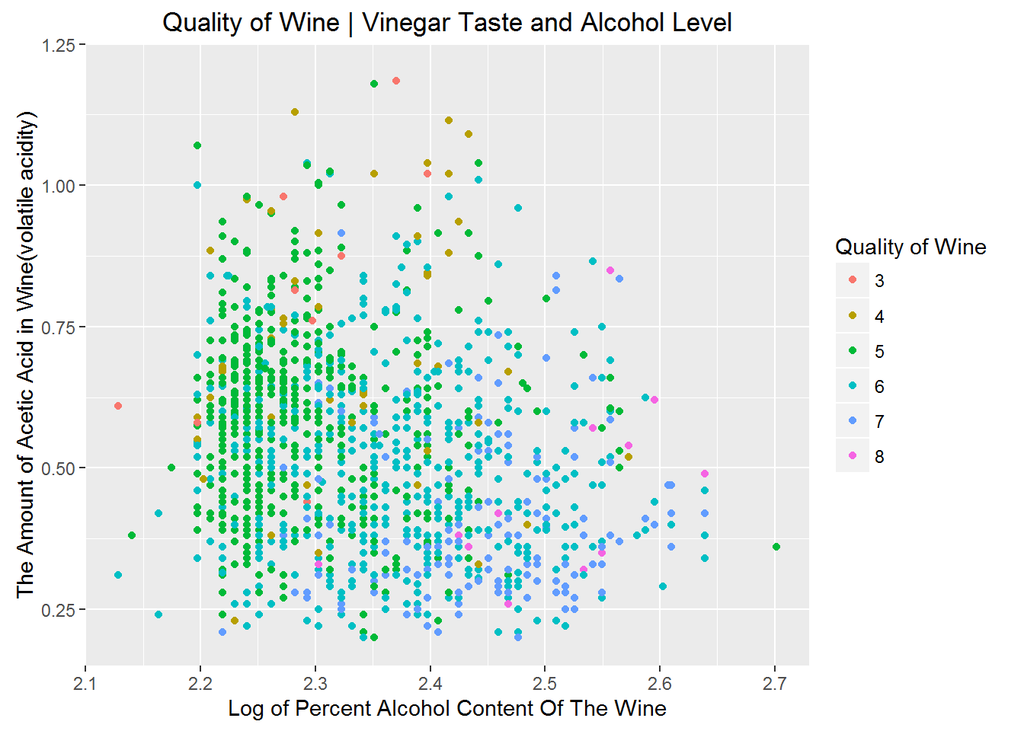

### Description Three

Last plot describe the relationships between Alcohol level, Vinegar taste, and the quality of wine. X-axis is the level of alcohol, Y-axis is the volatile acidity (Vinegar Taste) and the point are the distribution of wine colored by its quality.

As it was investigated in plot two, Alcohol level has positive effects on quality of wine, and Vinegar Taste (volatile acidity) has negative effects on quality of wine.

It is interesting to see the combination of the two attribution are important to decide the quality of wine.

For example, even if the alcohol level is very high around 2.4%-2.5% (log transformed), there are still tends to see the quality 3 or 4 wines if the level of Vinegar Taste is high.

Therefore, in terms of deciding quality of wine, the combinations of the attributes inside wine is important.

# Reflection

Using data set of 1599 wines and its 11 attributes which quality are graded by human from 1 to 10, I first see the distribution of the wine falls into mainly quality grade “5” to “6”.

Then I also investigate the relationship of the attributes with the quality of the red wine, and we found that the some seems have positive or negative effects on the quality of the wine but others not.

The level of the alcohol seems to have strong effects on the quality of the red wine, the higher the alcohol level, better quality of the red wine. Also, we found that volatile.acidity, which is also known as Vinegar Taste, has relatively strong negative effects on the quality of the wine.

When human deciding the quality of the wine, which is subjective value, it is definitely not the simple addition of the all the chemicals inside the wine. Therefore the simple liner regression model might have limitation to capture the true “quality” of the wine.

But we still can see some relationships what determine the quality of the wine, and main components that decide the quality of wine.

I can see that I can still investigate this question using other than liner regression modeling, such as non-liner model or classification modeling.